# Statistical Analysis of Biomarkers

Alejandro Cáceres, PhD  
Almirall, 10th of June 2020

### Presentation

- **Senior statistician** in the Bioinformatics group at Barcelona Institute of Global Health https://www.isglobal.org/
- Adjunct **lecturer** in statustics at the Universitat Politectica de Catalunya https://eebe.upc.edu/es
- Over 13 years of experience analysing biomedical data
- Develop novel analysis methods for **biomarker discovery**
- High dimensional data including imaging and omic data: genomic, transcriptomic, exposomic, etc.
- I write scientific articles and implement methods in software packages (R/Matlab).

### Presentation

You can find me at:

- [linkedin](https://es.linkedin.com/in/alejandro-caceres-dominguez-7449aa176)
- [google scholar](https://scholar.google.es/citations?user=s1D-6WAAAAAJ&hl=es)
- [gitHub](https://github.com/alejandro-isglobal)
- [my blog](https://alejandro-isglobal.github.io/)

### Presentation

Analytical validation of a biomarker: Functional magnetic resonance imaging

[figure not shown]

### Presentation

Discovery of severity Biomarker: Chromsome Y function and risk of disease in men

[figure not shown]

### Summary

- Introduction:
  - Biomarkers definition
  - Guidance for qualification and reporting
- Analysis methods for biomarkers:
  - Diagnostic matrix and ROC curve
  - Regression analyeses (stratified and with interactions)
  - Statistical power
  - Multiple Biomarkers
- Examples:
  - Prediction of drug effects (depresion)
  - Response to a therapeutic intervention (psoriasis)

### Introduction

Definition:

- A biomarker is a **biological measurement**.

Properties:

- Source material or matrix
- Method of measurement

### Introduction

Source material or matrix:

- specific analyte (e.g., cholesterol)
- anatomic feature (e.g., joint angle)
- physiological characteristic (e.g., blood pressure)

when they are composite

- how the compoenents are interrelated (e.g. genomic data)
- how is the process of obtaining the biomarker (e.g. algorithm, score)

### Introduction

Method of measurement:

- molecular
- histologic
- radiographic
- physiologic characteristic

New biomarkers are continously created as novel methods of measurements and their analysis are constantly developed for adressing outstanding disease-related or treatment-related **needs**.

### Introduction

Context of use (COU):

- diagnostic biomarker
- monitoring biomarker
- pharmacodynamic/response biomarker (e.g., clinical trial endpoints, including surrogate endpoints)
- predictive biomarker
- prognostic biomarker
- safety biomarker -susceptibility/risk biomarker

See FDA's Biomarker Qualification 2018 [doc](https://alejandro-isglobal.github.io/teaching/docs/fdabiomarker.pdf)

### Introduction

| Role | Description |
| --- | --- |
| Diagnosis of a disease | To make a diagnosis more reliably, more rapidly, or more inexpensively than available methods |
| Severity assessment | To identify subgroup of patients with a severe form of a disease associated with an increased probability of death or severe outcome |
| Risk assessment | To identify subgroup of patients who may experience better (or worse) outcome when expose to an intervention |
| Prediction of drug effects | To identify the pharmacological response of a patient exposed to a drug (efficacy, toxicity, and pharmacokinetics) |
| Monitoring | To assess the response to a therapeutic intervention |

### Analysis methods for Biomarker development

**Is the test reliable?**

Analytical considerations:

- validation of the Biomarkers test’s technical performance
- cost-effectives, feasability
- assessment of measurement error

To which extent individuals obtain the same measurement, if we were to repeat it?

**test-retest reliability studies**

Statistics:

- intra-class correlation coefficients
- Cohen's kappa
- correlation coefficients

### Analysis methods for Biomarker usefullness

**Is the test a clinically useful biomarker?**

Establish the relationship between a biomarker and an outcome of interest:

- Randomized controlled trial
- Single-arm/historical control trial
- Cohort study
- Case-control study (including nested)
- Cross-sectional study
- Case series or case reports
- Registry information
- Meta-analysis

Strongest evidence comes from **prospective studies** that are specifically designed but data from studies conducted for **other purposes** can be used to support biomarker qualification.

### Diagnostic Matrix

Supose we have gathered data for reponse/no-reponse (case/control) subjects and positive/negative test for each subject

The Respose measurement has to events:

- yes
- no

The Test measurement has to events:

- positive
- negative

### Diagnostic Matrix

Each individual has two measurements: (Response, Test)

| – Subject – | – Reponse – | – Test – |
| --- | --- | --- |
| \( s_1 \) | yes | positive |
| \( s_2 \) | no | negative |
| \( s_3 \) | yes | positive |
| … | … | … |
| \( s_i \) | no | positive* |
| … | … | … |
| … | … | … |
| \( s_3 \) | yes | negative* |
| … | … | … |

### Diagnostic Matrix

Let's think first in terms of the response

Within those who responded (yes), how many tested positive?

- **Sensitivity** (true positive rate)

### Diagnostic Matrix

Let's think first in terms of the response

Within those who did not respond (no), how many tested negative?

- **Especificity** (True negative rate)

\[ fr(negative|no)=\frac{n_{negative|no}}{n_{positive|no}+n_{negative|no}} \]

### Diagnostic Matrix

|  | -Response: Yes – | – Response: No – |
| --- | --- | --- |
| -**Test: positive**- | \( fr(positive\|yes) \) | \( fr(positive\|no) \) |
| -**Test: negative**- | \( fr(negative\|yes) \) | \( fr(negative\|no) \) |
| -**sum**- | 1 | 1 |

[output not shown]

Trade-off between sensitivity and especificity need to be evaluated in the context of use and usefullness of the test

### Diagnostic Matrix

Let's think first in terms of the test

Within those whose test was positive, how many responded (yes)?

- **Positive predictive value**

\[ fr(yes|positive)=\frac{n_{yes|positive}}{n_{yes|positive}+n_{no|positive}} \]

### Diagnostic Matrix

Let's think first in terms of the test

Within those whose test was negative, how many did not respond (no)?

- **Negative predictive value**

### Diagnostic Matrix

|  | -Response: Yes – | – Response: No – | – sum – |
| --- | --- | --- | --- |
| -**Test: positive**- | \( PPV: fr(yes\|positive) \) | \( fr(no\|positive) \) | 1 |
| -**Test: negative**- | \( fr(yes\|negative) \) | \( NPV: fr(no\|negative) \) | 1 |

PPV: positive predicted value NPV: negative predicted value

These are really the values that we want to know but they depend on the prevalence of the disease

### Diagnostic Matrix

There is a way to convert from sentitivity to positive predicted value (Baye's rule)

\[ fr(yes|possitive)=\frac{fr(positive|yes)}{fr(possitive)}fr(yes) \]

which can be rewritten

\[ \frac{fr(yes|possitive)}{fr(no|possitive)}=\frac{fr(positive|yes)}{1-fr(negative|no)} \frac{fr(yes)}{1-fr(yes)} \]

### Diagnostic Matrix

\[ ODD_{posttest}=LHR*ODD_{pretest} \]

\( LHR+=\frac{Sensitivity}{1-Especificity} \)

|  | LHR+ |
| --- | --- |
| Excellent diagnostic value | >10 |
| Good diagnostic value | 5-10 |
| Poor diagnostic value | 1-5 |
| No diagnostic value | 1 |

### ROC curve

Let's look at some data:

[HIV resistance](https://pubmed.ncbi.nlm.nih.gov/12060770)

- Biomarker: Resistance factor derived drom genomic data using a machine learning method
- Reponse: Antiretroviral drug resistance

### ROC curve

```r
library(RCurl)
hiv <- read.delim("https://alejandro-isglobal.github.io/data/hiv.txt")
head(hiv)
```

```
  response      test
1        1 -0.438185
2        1 -0.766791
3        1  0.695282
4        1 -0.689079
5        1  0.325977
6        1  0.704040
```

### ROC curve

```r
table(hiv$response)
```

```
 -1   1
267  78
```

- response: **yes**, resitstance to drug treatment: **1**
- response: **no**, no resitstance to drug treatmen: **-1**

### ROC curve

```r
br <- seq(-2,2,0.25)

hist(hiv$test[hiv$response==-1],
     br=br, freq=F,xlab="RF", main="")

hist(hiv$test[hiv$response==1],
     br=br, freq=F, add=T, col="blue")

legend("toprigh",
       legend=c("no resis.", "resis."),
       col=c(1,2), lty=1)
```

### ROC curve

[figure not shown]

### ROC curve

\( Test: positive > -0.5 \) when there was no resistance (no)

False positive rate: \( fr_{[cutoff=-0.5]}(positive|no)=0.05 \)

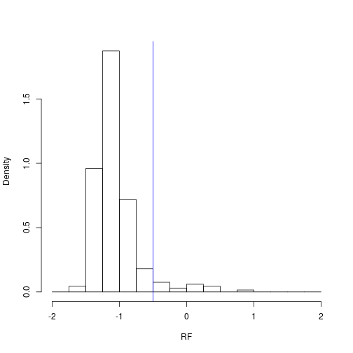

### ROC curve

\( Test: positive > -0.5 \) when there was resistance (yes)

True positive rate: \( fr_{[cutoff=-0.5]}(positive|yes)=0.73 \)

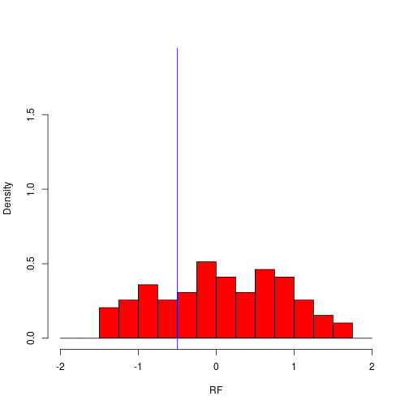

### ROC curve

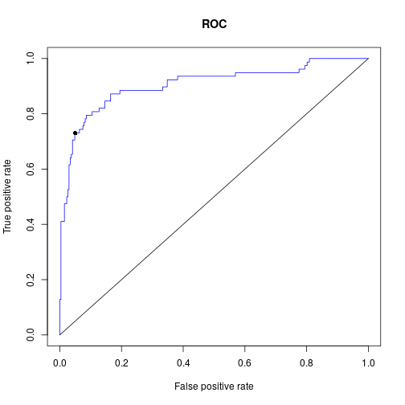

```r
library(cvAUC)
out <- cvAUC(hiv$test, hiv$response) #calcular ROC
plot(out$perf, col="blue", main="ROC") #plot
lines(c(0,1),c(0,1)); points(0.05, 0.73, pch=16) #cutoff=-0.5
```

### ROC curve

Area under the curve

\( AUC=Pr(Test_2|no < Test_1|yes) \)

```r
ci.cvAUC(hiv$test, hiv$response)
```

```
$cvAUC
[1] 0.9047825

$se
[1] 0.02276935

$ci
[1] 0.8601554 0.9494096

$confidence
[1] 0.95
```